# Diving Analysis To Improve Subscriber (Cyclistic)

Fransiscus Nauli Togatorop

2023-02-16

## Important Notes

Notes: “I work on this Cyclistic datasets from the course 8 Google Data Analytics portfolio project. Source of code for me to be able finished this project is from the user named Julian Schattenberg at http://bit.ly/3xw2hJj. With the help of ChatGPT, i also learned about what is done on the code.”

## Install the necessary packages

Installing tidyverse and lubridate packages with repository (repos) argument for setting the mirror at “https://cloud.r-project.org/”

```r
install.packages("tidyverse", repos = "https://cloud.r-project.org/")
install.packages("lubridate", repos = "https://cloud.r-project.org/")
install.packages("hms", repos = "https://cloud.r-project.org/")
```

Loading the packages

```r
library(tidyverse)
library(lubridate)
library(hms)
```

## Read the datasets and put them into variables

reading the .csv file using read.csv() function

```r
q1_trips <- read.csv("Divvy_Trips_2019_Q1.csv")
q2_trips <- read.csv("Divvy_Trips_2019_Q2.csv")
q3_trips <- read.csv("Divvy_Trips_2019_Q3.csv")
q4_trips <- read.csv("Divvy_Trips_2019_Q4.csv")
```

## Check the similarity of the columns between the datasets

checking the columns by using colnames() function and compare it between variables using operator ==

```r
colnames(q1_trips) == colnames(q2_trips)
```

```
##  [1] FALSE FALSE FALSE FALSE FALSE FALSE FALSE FALSE FALSE FALSE FALSE FALSE
```

```r
colnames(q1_trips) == colnames(q3_trips)
```

```
##  [1] TRUE TRUE TRUE TRUE TRUE TRUE TRUE TRUE TRUE TRUE TRUE TRUE
```

```r
colnames(q1_trips) == colnames(q4_trips)
```

```
##  [1] TRUE TRUE TRUE TRUE TRUE TRUE TRUE TRUE TRUE TRUE TRUE TRUE
```

## Overwrite column names in q2 with the names from q1 variable

overwriting the columns by using setNames() function

```r
q2_trips <- setNames(q2_trips, colnames(q1_trips))
```

## Combine the datasets into one variable year2019

combining with the rbind() function. note: rbind() function only works when the columns name between variables is all same.

```r
year2019 <- rbind(q1_trips,q2_trips,q3_trips,q4_trips)
```

## Check the overview of year2019

```r
str(year2019)
```

```
## 'data.frame':    3818004 obs. of  12 variables:
##  $ trip_id          : int  21742443 21742444 21742445 21742446 21742447 21742448 21742449 21742450 21742451 21742452 ...
##  $ start_time       : chr  "2019-01-01 00:04:37" "2019-01-01 00:08:13" "2019-01-01 00:13:23" "2019-01-01 00:13:45" ...
##  $ end_time         : chr  "2019-01-01 00:11:07" "2019-01-01 00:15:34" "2019-01-01 00:27:12" "2019-01-01 00:43:28" ...
##  $ bikeid           : int  2167 4386 1524 252 1170 2437 2708 2796 6205 3939 ...
##  $ tripduration     : chr  "390.0" "441.0" "829.0" "1,783.0" ...
##  $ from_station_id  : int  199 44 15 123 173 98 98 211 150 268 ...
##  $ from_station_name: chr  "Wabash Ave & Grand Ave" "State St & Randolph St" "Racine Ave & 18th St" "California Ave & Milwaukee Ave" ...
##  $ to_station_id    : int  84 624 644 176 35 49 49 142 148 141 ...
##  $ to_station_name  : chr  "Milwaukee Ave & Grand Ave" "Dearborn St & Van Buren St (*)" "Western Ave & Fillmore St (*)" "Clark St & Elm St" ...
##  $ usertype         : chr  "Subscriber" "Subscriber" "Subscriber" "Subscriber" ...
##  $ gender           : chr  "Male" "Female" "Female" "Male" ...
##  $ birthyear        : int  1989 1990 1994 1993 1994 1983 1984 1990 1995 1996 ...
```

```r
summary(year2019)
```

```
##     trip_id          start_time          end_time             bikeid
##  Min.   :21742443   Length:3818004     Length:3818004     Min.   :   1
##  1st Qu.:22873787   Class :character   Class :character   1st Qu.:1727
##  Median :23962320   Mode  :character   Mode  :character   Median :3451
##  Mean   :23915629                                         Mean   :3380
##  3rd Qu.:24963703                                         3rd Qu.:5046
##  Max.   :25962904                                         Max.   :6946
##
##  tripduration       from_station_id from_station_name  to_station_id
##  Length:3818004     Min.   :  1.0   Length:3818004     Min.   :  1.0
##  Class :character   1st Qu.: 77.0   Class :character   1st Qu.: 77.0
##  Mode  :character   Median :174.0   Mode  :character   Median :174.0
##                     Mean   :201.7                      Mean   :202.6
##                     3rd Qu.:289.0                      3rd Qu.:291.0
##                     Max.   :673.0                      Max.   :673.0
##
##  to_station_name      usertype            gender            birthyear
##  Length:3818004     Length:3818004     Length:3818004     Min.   :1759
##  Class :character   Class :character   Class :character   1st Qu.:1979
##  Mode  :character   Mode  :character   Mode  :character   Median :1987
##                                                           Mean   :1984
##                                                           3rd Qu.:1992
##                                                           Max.   :2014
##                                                           NA's   :538751
```

```r
unique(year2019$usertype)
```

```
## [1] "Subscriber" "Customer"
```

## Checking for missing values in year2019

using for loop method to checking the missing values with is.na() function in each columns. combining also with message function, so when missing values are detected, r will sending a message.

```r
for (f in 1:12) {
  message(sum(is.na(year2019[f])), "missing values in columns", f)}
```

```
## 0missing values in columns1
```

```
## 0missing values in columns2
```

```
## 0missing values in columns3
```

```
## 0missing values in columns4
```

```
## 0missing values in columns5
```

```
## 0missing values in columns6
```

```
## 0missing values in columns7
```

```
## 0missing values in columns8
```

```
## 0missing values in columns9
```

```
## 0missing values in columns10
```

```
## 0missing values in columns11
```

```
## 538751missing values in columns12
```

dropping the missing values with drop_na() function

```r
year2019 <- drop_na(year2019)
```

## Checking for empty fields

using for loop method to check the empty fields with sum() function looking for ” ”

```r
for (i in 1:12) {
  message(sum((year2019[i]== " ")), " empty fields in column", i)}
```

```
## 0 empty fields in column1
```

```
## 0 empty fields in column2
```

```
## 0 empty fields in column3
```

```
## 0 empty fields in column4
```

```
## 0 empty fields in column5
```

```
## 0 empty fields in column6
```

```
## 0 empty fields in column7
```

```
## 0 empty fields in column8
```

```
## 0 empty fields in column9
```

```
## 0 empty fields in column10
```

```
## 0 empty fields in column11
```

```
## 0 empty fields in column12
```

## Checking for distinct values

using for loop method to check any distinct values in each columns

```r
for (i in 1:12) {
  message(n_distinct(year2019[i]), "distinct values in column", i)}
```

```
## 3279253distinct values in column1
```

```
## 2890593distinct values in column2
```

```
## 2857108distinct values in column3
```

```
## 6013distinct values in column4
```

```
## 16062distinct values in column5
```

```
## 614distinct values in column6
```

```
## 638distinct values in column7
```

```
## 615distinct values in column8
```

```
## 639distinct values in column9
```

```
## 2distinct values in column10
```

```
## 3distinct values in column11
```

```
## 94distinct values in column12
```

```r
colnames(year2019)
```

```
##  [1] "trip_id"           "start_time"        "end_time"
##  [4] "bikeid"            "tripduration"      "from_station_id"
##  [7] "from_station_name" "to_station_id"     "to_station_name"
## [10] "usertype"          "gender"            "birthyear"
```

## Trimming extra spaces in $from_station_name and $to_station_name

using trimws() function to ensure no extra spaces between values

```r
year2019$from_station_name <- trimws(year2019$from_station_name)
year2019$to_station_name <- trimws(year2019$to_station_name)
```

## Converting all characters into lowercase

this step is using mutate_all() function with argument .funs = to lower

```r
year2019 <- mutate_all(year2019, .funs = tolower)
```

## Opting to drop column $from_station_name and $to_station_name

because of uncertainty of the values, opted to drop the columns using drop operator (-) in vector

```r
year2019 <- year2019[, -c(7, 9)]
```

checking after dropping columns

```r
colnames(year2019)
```

```
##  [1] "trip_id"         "start_time"      "end_time"        "bikeid"
##  [5] "tripduration"    "from_station_id" "to_station_id"   "usertype"
##  [9] "gender"          "birthyear"
```

## Opting to drop $end_time because less useful in later analysis

```r
year2019 <- year2019[, -3]
```

## Splitting $start_time column into $date and $time

using separate() function to separate the column, with separator ” ” (space)

```r
year2019 <- separate(year2019, col = start_time, into = c("date", "time"),
                     sep = " ")
colnames(year2019)
```

```
##  [1] "trip_id"         "date"            "time"            "bikeid"
##  [5] "tripduration"    "from_station_id" "to_station_id"   "usertype"
##  [9] "gender"          "birthyear"
```

## Removing comma in the $tripduration column

removing the comma character with gsub() function and checking the values with unique() function

```r
year2019$tripduration <- gsub(",", "",as.character(year2019$tripduration))
unique(year2019$tripduration)
```

[output not shown]

[output cut: 2662 more lines]

## Changing data format for further analysis

changing data format for each columns using necessary format function

```r
year2019$trip_id <- as.integer(year2019$trip_id) #from character to integer
year2019$bikeid <- as.integer(year2019$bikeid) #from character to integer
year2019$date <- as.Date(year2019$date) #from character to date
year2019$time <- as.hms(year2019$time) #from character to hms (hour,minute,second)
year2019$tripduration <- as.integer(year2019$tripduration) #from chr to integer
year2019$from_station_id <- as.integer(year2019$from_station_id) #from chr to integer
year2019$to_station_id <- as.integer(year2019$to_station_id) #from chr to integer
year2019$usertype <- as.factor(year2019$usertype) #from chr to factor
year2019$gender <- as.factor(year2019$gender) #from chr to factor
year2019$birthyear <- as.integer(year2019$birthyear) #from chr to factor
```

## Creating new columns hour (class 1-24), day(class mon-sun), month (Jan - Dec)

from the column start_time using intermediary column TotalTime. this can be done by using mutate() function combined with necessary format argument and ceiling_date() function

```r
year2019 <- mutate(year2019, TotalTime = as.POSIXct(time, format= '%T')
                   , hour = format(ceiling_date(TotalTime, '1 hours'), "%H%M")) %>%
  select(-TotalTime)
```

## Formatting $hour into integer, changing values from 0000 to 2400 and then remove the 00.

```r
year2019$hour[year2019$hour == "0000"] <- "2400"
unique(year2019$hour)
```

```
##  [1] "0100" "0200" "0300" "0400" "0500" "0600" "0700" "0800" "0900" "1000"
## [11] "1100" "1200" "1300" "1400" "1500" "1600" "1700" "1800" "1900" "2000"
## [21] "2100" "2200" "2300" "2400"
```

```r
year2019$hour <- as.integer(year2019$hour) #changing format into integer
year2019$hour <- year2019$hour / 100 #eliminating zeros in each values
unique(year2019$hour)
```

```
##  [1]  1  2  3  4  5  6  7  8  9 10 11 12 13 14 15 16 17 18 19 20 21 22 23 24
```

```r
year2019$hour  <- as.integer(year2019$hour)
str(year2019$hour)
```

```
##  int [1:3279253] 1 1 1 1 1 1 1 1 1 1 ...
```

## Dropping $time column

```r
year2019 <- year2019[, -3]
```

## Creating $day and $month columns

This can be done using weekdays() function for creating $day column and months() function for creating $month column. Both function extract the day of the week and month from the date column. Both weekdays() and months() function can only work if the data type is in date format. That is why as.Date() function is needed in the code.

```r
year2019$day <- weekdays(as.Date(year2019$date))
year2019$month <- months(as.Date(year2019$date))
colnames(year2019)
```

```
##  [1] "trip_id"         "date"            "bikeid"          "tripduration"
##  [5] "from_station_id" "to_station_id"   "usertype"        "gender"
##  [9] "birthyear"       "hour"            "day"             "month"
```

## Formatting $day and $month into factor

This needs to be done so we can go for further analysis

```r
year2019$day <- as.factor(year2019$day)
year2019$month <- as.factor(year2019$month)
```

## Dropping $date and $gender columns

```r
year2019 <- year2019[, -c(2, 8)]
colnames(year2019)
```

```
##  [1] "trip_id"         "bikeid"          "tripduration"    "from_station_id"
##  [5] "to_station_id"   "usertype"        "birthyear"       "hour"
##  [9] "day"             "month"
```

```r
summary(year2019)
```

```
##     trip_id             bikeid      tripduration     from_station_id
##  Min.   :21742443   Min.   :   1   Min.   :     61   Min.   :  2.0
##  1st Qu.:22826766   1st Qu.:1735   1st Qu.:    380   1st Qu.: 81.0
##  Median :23973095   Median :3465   Median :    632   Median :176.0
##  Mean   :23918354   Mean   :3390   Mean   :   1081   Mean   :205.2
##  3rd Qu.:25012391   3rd Qu.:5061   3rd Qu.:   1078   3rd Qu.:291.0
##  Max.   :25962904   Max.   :6946   Max.   :9056633   Max.   :673.0
##
##  to_station_id         usertype         birthyear         hour
##  Min.   :  2.0   customer  : 348217   Min.   :1759   Min.   : 1.00
##  1st Qu.: 81.0   subscriber:2931036   1st Qu.:1979   1st Qu.:10.00
##  Median :176.0                        Median :1987   Median :16.00
##  Mean   :205.7                        Mean   :1984   Mean   :14.65
##  3rd Qu.:293.0                        3rd Qu.:1992   3rd Qu.:18.00
##  Max.   :673.0                        Max.   :2014   Max.   :24.00
##
##         day               month
##  Friday   :503675   August   :486485
##  Monday   :498997   July     :456731
##  Saturday :365832   September:419408
##  Sunday   :319715   June     :387699
##  Thursday :527582   October  :331340
##  Tuesday  :532864   May      :309209
##  Wednesday:530588   (Other)  :888381
```

## Fixing $tripduartion column

checking the columns summary, need to fix the $tripduration because the max values are really high. min:61 s, median: 632 s, 3rd quar: 1078 s, max: 9056633 s

```r
year2019 <- subset(year2019, tripduration < 86401)
summary(year2019)
```

```
##     trip_id             bikeid      tripduration     from_station_id
##  Min.   :21742443   Min.   :   1   Min.   :   61.0   Min.   :  2.0
##  1st Qu.:22826784   1st Qu.:1735   1st Qu.:  380.0   1st Qu.: 81.0
##  Median :23973111   Median :3465   Median :  632.0   Median :176.0
##  Mean   :23918364   Mean   :3390   Mean   :  920.5   Mean   :205.2
##  3rd Qu.:25012398   3rd Qu.:5061   3rd Qu.: 1077.0   3rd Qu.:291.0
##  Max.   :25962904   Max.   :6946   Max.   :86400.0   Max.   :673.0
##
##  to_station_id         usertype         birthyear         hour
##  Min.   :  2.0   customer  : 347818   Min.   :1759   Min.   : 1.00
##  1st Qu.: 81.0   subscriber:2930537   1st Qu.:1979   1st Qu.:10.00
##  Median :176.0                        Median :1987   Median :16.00
##  Mean   :205.7                        Mean   :1984   Mean   :14.65
##  3rd Qu.:293.0                        3rd Qu.:1992   3rd Qu.:18.00
##  Max.   :673.0                        Max.   :2014   Max.   :24.00
##
##         day               month
##  Friday   :503530   August   :486346
##  Monday   :498887   July     :456582
##  Saturday :365674   September:419317
##  Sunday   :319604   June     :387615
##  Thursday :527452   October  :331265
##  Tuesday  :532732   May      :309143
##  Wednesday:530476   (Other)  :888087
```

## Fixing $birthyear

in $birthyear needs to fix the values because minimum values is 1759, which is unlikely situation

```r
year2019 <- subset(year2019, birthyear > 1924)
summary(year2019)
```

```
##     trip_id             bikeid      tripduration     from_station_id
##  Min.   :21742443   Min.   :   1   Min.   :   61.0   Min.   :  2.0
##  1st Qu.:22826875   1st Qu.:1735   1st Qu.:  380.0   1st Qu.: 81.0
##  Median :23973056   Median :3465   Median :  632.0   Median :176.0
##  Mean   :23918348   Mean   :3390   Mean   :  920.5   Mean   :205.1
##  3rd Qu.:25012314   3rd Qu.:5061   3rd Qu.: 1077.0   3rd Qu.:291.0
##  Max.   :25962904   Max.   :6946   Max.   :86400.0   Max.   :673.0
##
##  to_station_id         usertype         birthyear         hour
##  Min.   :  2.0   customer  : 347782   Min.   :1925   Min.   : 1.00
##  1st Qu.: 81.0   subscriber:2929544   1st Qu.:1979   1st Qu.:10.00
##  Median :176.0                        Median :1987   Median :16.00
##  Mean   :205.7                        Mean   :1984   Mean   :14.65
##  3rd Qu.:293.0                        3rd Qu.:1992   3rd Qu.:18.00
##  Max.   :673.0                        Max.   :2014   Max.   :24.00
##
##         day               month
##  Friday   :503360   August   :486212
##  Monday   :498695   July     :456474
##  Saturday :365564   September:419190
##  Sunday   :319533   June     :387543
##  Thursday :527289   October  :331132
##  Tuesday  :532606   May      :309079
##  Wednesday:530279   (Other)  :887696
```

## Creating new dataframe year2019_usertype ($birthyear, $usertype) for visualization

this dataframe needed to see the relation between age of the usertype to the usertype.

```r
colnames(year2019)
```

```
##  [1] "trip_id"         "bikeid"          "tripduration"    "from_station_id"
##  [5] "to_station_id"   "usertype"        "birthyear"       "hour"
##  [9] "day"             "month"
```

```r
year2019_usertype <- year2019[,c(6,7)] %>%
  group_by(usertype, birthyear) %>%
  summarise(n=n()) %>%
  group_by(usertype) %>%
  mutate(percentage= 100*n/sum(n))
head(year2019_usertype)
```

```
## # A tibble: 6 × 4
## # Groups:   usertype [1]
##   usertype birthyear     n percentage
##   <fct>        <int> <int>      <dbl>
## 1 customer      1925     2   0.000575
## 2 customer      1928     3   0.000863
## 3 customer      1931     1   0.000288
## 4 customer      1935     3   0.000863
## 5 customer      1936     1   0.000288
## 6 customer      1937     4   0.00115
```

## Plotting the dataframe

this can be done using ggplot() function

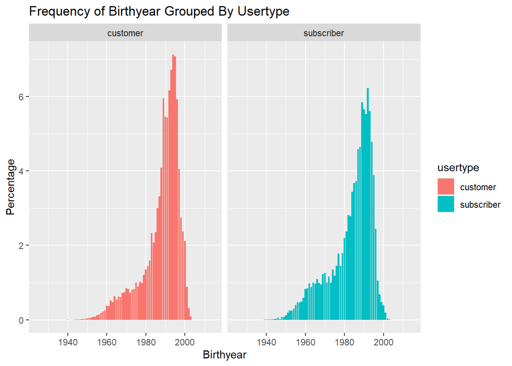

```r
ggplot(year2019_usertype)+
  geom_bar(aes(x= birthyear, y= percentage, fill= usertype), stat="identity")+
  ylab("Percentage")+
  xlab("Birthyear")+
  facet_wrap(~usertype)+
  labs(title = "Frequency of Birthyear Grouped By Usertype")+
  theme(legend.position = "right")
```

## Checking on percentage of people born in 1999 or later in the customer or subscriber group

this way we can see the percentage of younger rider

```r
cus_1999_later <- sum(year2019_usertype$percentage [year2019_usertype$birthyear>1998
                                                    & year2019_usertype$usertype== 'customer'])
```

percentage of people born in 1999 or later in the customer is 5.77 %

```r
sub_1999_later <- sum(year2019_usertype$percentage
                      [year2019_usertype$birthyear>1998
                        & year2019_usertype$usertype== 'subscriber'])
```

percentage of people born in 1999 or later in the subscriber is 1.11 %

## Creating new dataframe year2019_month (month, usertype) for visualization

```r
year2019_month <- year2019[, c(6,10)] %>%
  group_by(usertype, month) %>%
  summarise(n=n()) %>%
  group_by(usertype) %>%
  mutate(percentage=100*n/sum(n))
```

## Creating new dataframe year2019_day (day, usertype) for visualization

```r
year2019_day <- year2019[, c(6,9)] %>%
  group_by(usertype, day) %>%
  summarise(n=n()) %>%
  group_by(usertype) %>%
  mutate(percentage= 100*n/sum(n))
```

## Plotting frequency of each month group by usertype

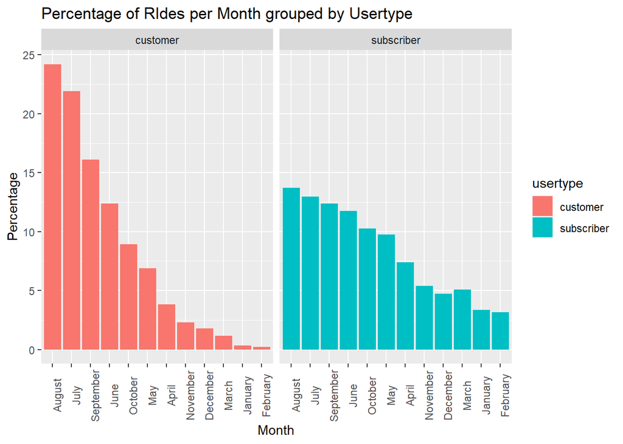

```r
ggplot(year2019_month)+
    geom_bar(aes(x= reorder(month, -percentage), y= percentage, fill= usertype)
             , stat="identity")+
    ylab("Percentage")+
    xlab("Month")+
    facet_wrap(~usertype)+
    labs(title = "Percentage of RIdes per Month grouped by Usertype")+
    theme(legend.position = "right", axis.text.x = element_text(angle = 90))
```

checking the sum of the customer group by each month

```r
table(year2019$month [year2019$usertype== "customer"])
```

```
##
##     April    August  December  February   January      July      June     March
##     13258     84139      6242       737      1205     76186     43010      4082
##       May  November   October September
##     23933      7932     31002     56056
```

## Checking the sum of customer from July to September

```r
message(round(sum(year2019_month$percentage [year2019_month$usertype== "customer" &
                                               (year2019_month$month=="Juli" |
                                                  year2019_month$month=="August"|
                                                  year2019_month$month=="September")]), 2)
        , "% of all customer trips occur in the months of July, August and September")
```

[output not shown]

## Plotting frequency of day group by usertype

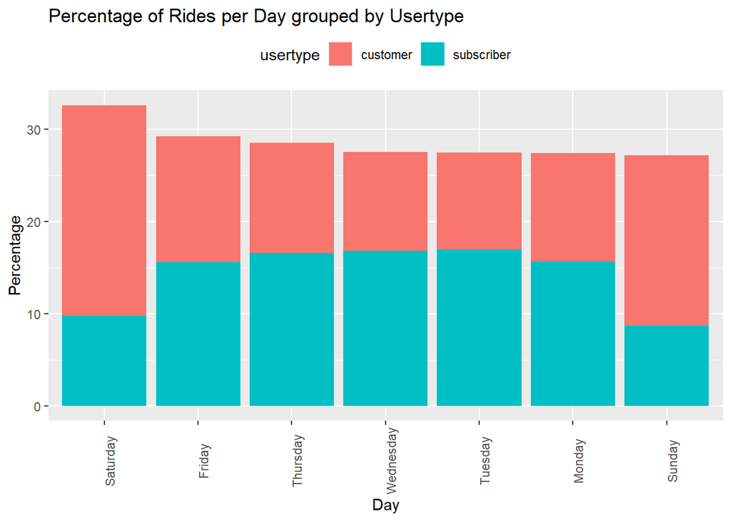

```r
ggplot(year2019_day)+
  geom_bar(aes(x= reorder(day, -percentage), y=percentage, fill=usertype)
           , stat="identity")+
  ylab("Percentage")+
  xlab("Day")+
  labs(title= "Percentage of Rides per Day grouped by Usertype")+
  theme(legend.position = "top", axis.text.x = element_text(angle = 90))
```

```r
table(year2019$day [year2019$usertype== "customer"])
```

```
##
##    Friday    Monday  Saturday    Sunday  Thursday   Tuesday Wednesday
##     47604     41074     79410     64130     41590     36765     37209
```

## Retrieving the percentage of customer per day

```r
message(round(sum(year2019_day$percentage [year2019_day$usertype== "customer"
                                           & (year2019_day$day== "Saturday"
                                           | year2019_day$day== "Sunday")]), 2)
        , "% of all customer trips occur on the weekends")
```

```
## 41.27% of all customer trips occur on the weekends
```

the message result is 41.27% of all customer trips on the weekends

## Calculating mean for each group

```r
avg_td_cus <- mean(year2019$tripduration[year2019$usertype=='customer'])
avg_td_sub <- mean(year2019$tripduration[year2019$usertype=='subscriber'])
```

average of duration per customer is 2145.34 seconds average of duration per subscriber is 775.1 seconds

## Creating histogram plot to see the difference in the distribution

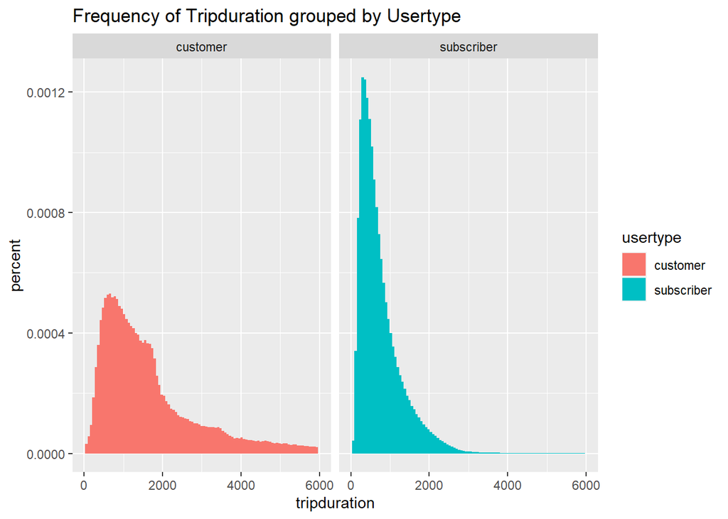

```r
ggplot(year2019, aes(tripduration, fill= usertype))+
  geom_histogram(aes(y= stat(density)), binwidth = 60)+
  scale_y_continuous("percent")+
  facet_wrap(~usertype)+
  xlim(0, 6000)+
  theme(legend.position = "right")+
  labs(title= "Frequency of Tripduration grouped by Usertype")
```